# Explore Gmat

### Making the gmat bimodal

I convert any value that is different from 0 to 1. I select for LSI genes that are accessible in more than 500 cells.

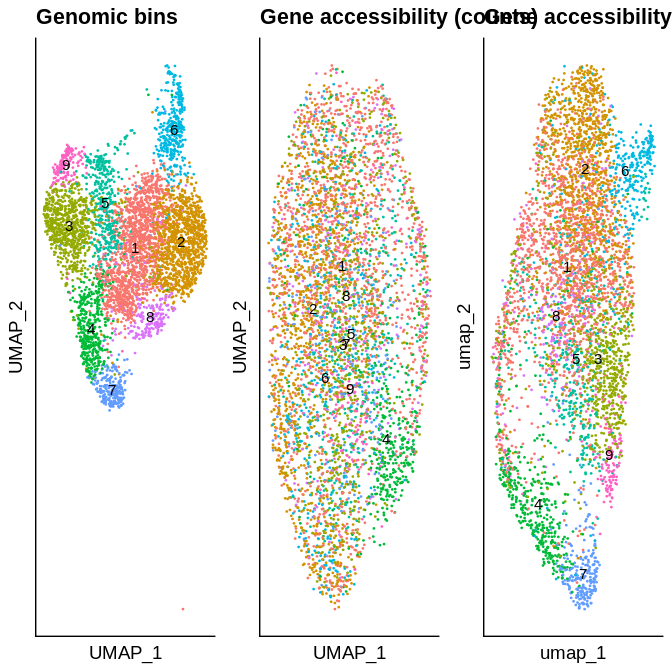

Selecting features based on coverage still enables better segregation of clusters compared to the RNA HVGs.

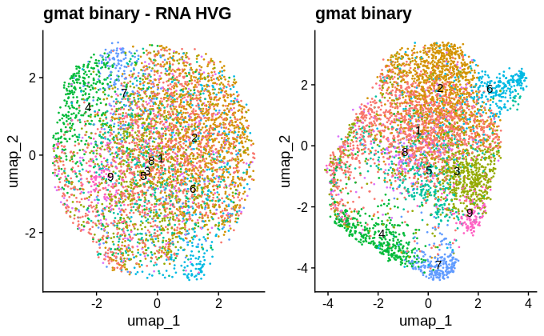

### Feature selection based on number of cells with accessible site

Selecting genes that are covered in at least 10% of the cells (~ 8000 genes in this case) still maintains the structure from the bmat.

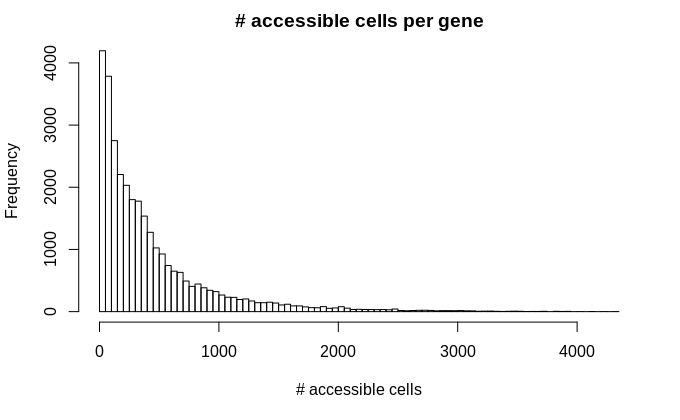

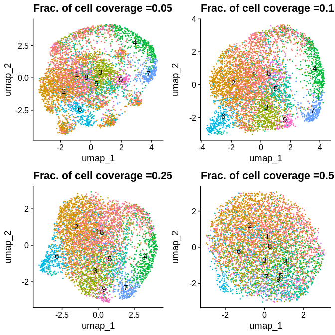